# Docker Intro

Oyogo

8/27/2021

# Docker

Docker is a computer system that helps you to create a loosely isolated environment (from your computer) called a container for your application(s). The environment is isolated from host machine in the sense that the container can have an application, operating system with a different version and dependencies from the ones existing on your host machine, in other words, we can have an R version 3.1.2 inside the container while in the host machine we have R version 3.4.1.

**Why docker?**  
* Shiny is single threaded, this means multiple users of an app use one session which often times creates problems. This is solved by containerization because with docker every user gets a spinned container of the shiny app.  
* Often times packages and dependencies bring problems when they get updated such that a shiny application which was working stops working just because some version of a package previously used was updated to another version.

# Docker architecture

The following image gives us an overview of how the docker system works

[figure not shown]

**docker client**:  
The client provides the user a command line interface where you run docker commands that talk to the docker daemon through an API.

**docker daemon**:  
This is the manager of docker objects ; images, containers, networks, and volumes.

- *images*: this is a file with instructions used to create a container. An image is created from a Dockerfile.
- *Dockerfile*: this is a text file with instructions/commands for building an image.
- *container*: a runnable instance of an image.
- *network*: a system of connecting docker containers.

**docker registry**:  
This is where docker images are stored, shared and managed.

# Installation

Docker system is built on linux however, for windows and Mac users you can still install a desktop version as explained in the procedures below:

[Installing docker on Mac](https://hub.docker.com/editions/community/docker-ce-desktop-mac)  
[Installing docker on Windows](https://hub.docker.com/editions/community/docker-ce-desktop-windows)

# Dockerfile

Below is a simple example of a Dockerfile that I built from the Education app that I developed earlier in this article.

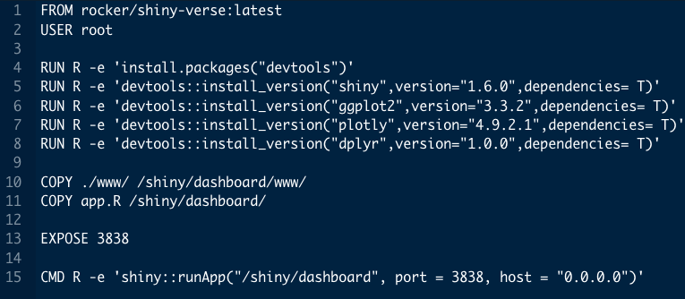

*On your commandline you can use *touch Dockerfile* to create an empty file to begin with then use your preferred text editor to add layers to it..*

**FROM**  
This is the first layer of our dockerfile, it specifies the base image that will be used to build the new image. Every dockerfile starts with this layer and you will often times use another image as your starting point. An alternative way would be starting from scratch by installing the required dependencies but that would be more work which may not be necessary.

**USER**  
This command specifies the user, in this case *root*. The specified user will be used to run the subsequent *RUN*, *COPY*, *EXPOSE* and *CMD* commands.

**COPY**  
The copy command copies files or directories from the host machine to the container.  
The command has two paths:  
- path-in-host and path-in-container It takes the form:  
*for files*  
*path-in-host/file.txt* *path-in-container/* notice there is a space between the two paths. an example is: /rprojects/mydash1/app.R /rprojects/mydash1/ from the above line we’re copying the file *app.R* from the folder *mydash1* which is inside *rprojects* into the folder mydash under rprojects folder in the container.

*for folders*  
*path-in-host/myfolder/* *path-in-container/*

- if you don’t put the forward slash at the end of the folder name it will be treated as a file not a folder.
- when copying *myfolder* only the contents will be copied into *path-in-container*, to create *myfolder* then write  
  *path-in-container/myfolder/  
  By writing it that way - *myfolder* will be created in the container file system without necessarily using mkdir command and then,  
  the contents of *myfolder* from the host machine will be pasted therein.
- If by any chance your path has white space i.e projects/my folder/ then use COPY [“/projects/my folder/”, “/projects/my folder/”]
- If you have multiple files say starting with mod… then you can copy all of them using COPY mod* /myfolder/ . All files starting with mod will be copied.

For our case the first line copies the www folder which contains some images we’ve used. The second line copies the app.R script file which has the ui and the server code for building our application.

**RUN**  
This instruction executes the given command inside the container. In this case we have used it to install necessary packages inside the container.  
Notice that we started with installing devtools first such that we can use it to install specific versions of the required packages.

**EXPOSE 3838** This command instructs the container to open up the network port 3838 to the outside world.

# Building the image.

Once we’ve written our dockerfile as explained above navigate to the working directory containing you application files and the following command to build the image:

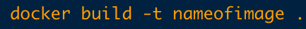

docker build is the command for building docker image from dockerfile.  
The -t tags our image as in giving our image a name.  
The . instructs docker to use the dockerfile in the current folder.  
N/B remember to replace the nameofimage to your desired name. If you have a docker hub account you can use *yournameindockerhub/nameofimage*

# Spinning the container

Remember our application used data and if you were keen we did not add a volume in our docker file

Finally you can now check *locahost:3838* on our browser to see your containerized application.